[figure not shown]

Vacuum Pump Control System

WIRING SYSTEM

57.Vacuum Pump Control System

A: WIRING DIAGRAM

WI-44599

12

11

13

B:

E158

A:

B134

F134

B564

B565

B564

6

5

8

7

B220

10

B1

13

B550

1

J/C

B37

B13

A38

A18

A19

A10

2

3

1

B14

E3

B22

B122

1

1

B:

B143

A:

F37

B4

A16

A8

2

1

A9

A

B

W/R

G2

1

G

W/R

Y/L Y/L

B/W

LG

R/L

W/B

30A

WW

W/R2

15 11

W/R

W12

15A

L/B

Y/B

LG

L/Y

G/R

R

B/L

L/Y

G/W

B

Y/B

B/L

B/W

W/B

L/B

R/L

G/W

G/R

M/B

W/B

B

W/R

B

B

W/R

L

R

L

MB-23

SBF-7

(B)

ECM

FUSE HOLDER

MAIN RELAY

BRAKE BOOSTER

PRESSURE SENSOR

BRAKE PUMP RELAY

BRAKE PUMP FUSE

VACUUM

PUMP

: TERMINAL No. OPTIONAL ARRANGEMENT

REF. TO GND [b]

MB-33

MAIN SBF

(B)

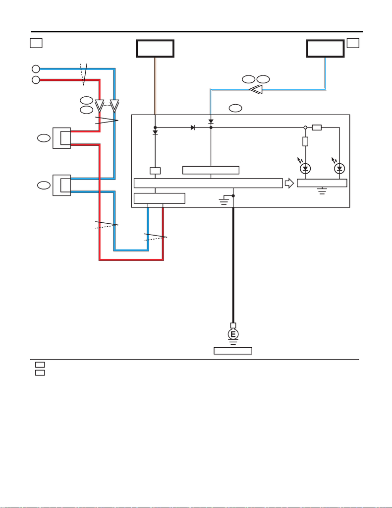

WI-410

Vacuum Pump Control System

WIRING SYSTEM

WI-44600

3

b b

i229

i233

i232

B551

A

B

i10

I/F

W/L W/L

J/C

J/C

B

40

20

38

R33

L32

W/L

BR/WBR/W

B

W/L

1R

1R

1L

1L

R

L

7

6

i229

B551

EJ

FA

FA

EJ

POWER SUPPLY CIRCUIT

FB-18

F/B FUSE NO. 7

(B)

DRIVE CIRCUIT

MICRO COMPUTER

CAN TRANSCEIVER &

RECEIVER

COMBINATION

METER

FB-12

F/B FUSE NO. 2

(IG)

1

: TERMINAL No. OPTIONAL ARRANGEMENT

REF. TO GND [e]

PARKING BRAKE/

BRAKE FLUID LEVEL/

BRAKE VACUUM PUMP

: ENGINE TYPE EJ

: ENGINE TYPE FA

PARKING BRAKE/

BRAKE FLUID LEVEL

[figure not shown]

WI-411

Vacuum Pump Control System

WIRING SYSTEM

WI-44601

c c

(BR)

B22

12

3

4

5678

9

10 11 12

1413 15 16

34

2

1

78

5

6

B122

(GR)

10

11 12

23 24

35 36

47 48

3

5

6

7894

12

45

21

2219 2017 1815 1613 14

33

3431 3229 3027 2825 26

(BR)

B134

A:

89

19 20

1234 567

10 11 12 13 14 15 16 17 18

B143

B:

B220

10 11

12

13

14 15

16

18

19 21 22

20

17

24

5

3

17

9

8

6

32 33

34

35

28262423

25

27

29

30

31

36 37

38

40

41 43 44

42

39

91

2

232221 262524201918

4

13

12

17

3

16

6

15

587

14

10 11

B550

(B)

B564

3

4

12

9

5

7

8

6

10

12

13

11

14

16

17

15

123

(B)

B565

E158

(B)

79

10

85

23

11 12

6

19 21 222017

24

35 36

47 48

18

31 33 343229 30

43 45 464441 42

3412

15 1613 14

27 2825 26

39 4037 38

B:

F37A:

1234

56789

10 11 12 13 14 15 16 17 18 19 20

F134

(GR)

12

i10

11 12

9

10

7856341

2

15 1613 14 19

18

20

21 22 23 24 26

25

27 28 29 30 31 32 33 34 35 36 37 38 39 40

17

i233

i232

78

5

6

34

21

i229

12 345

6789

10 11 12

LIST OF CONNECTORS

RELAY HOLDER

RELAY HOLDER

FUSE HOLDER